# Risk Factor Analysis

## Outcome Variable

**Outcome Variable:** ever_wasted

## Predictor Variables

**Intervention Variable:** fage

**Adjustment Set:**

- arm
- W_mage
- meducyrs
- feducyrs
- W_mhtcm
- W_mwtkg
- W_mbmi
- W_fhtcm
- single
- brthmon
- delta_W_mage
- delta_meducyrs
- delta_feducyrs
- delta_W_mhtcm
- delta_W_mwtkg
- delta_W_mbmi
- delta_W_fhtcm
- delta_single
- delta_brthmon

## Stratifying Variables

The analysis was stratified on these variable(s):

- agecat
- studyid
- country

## Data Summary

| agecat | studyid | country | fage | ever_wasted | n_cell | n |
| --- | --- | --- | --- | --- | --- | --- |
| 0-24 months | COHORTS | GUATEMALA | >=38 | 0 | 285 | 1285 |
| 0-24 months | COHORTS | GUATEMALA | >=38 | 1 | 97 | 1285 |
| 0-24 months | COHORTS | GUATEMALA | <32 | 0 | 453 | 1285 |
| 0-24 months | COHORTS | GUATEMALA | <32 | 1 | 148 | 1285 |
| 0-24 months | COHORTS | GUATEMALA | [32-38) | 0 | 218 | 1285 |
| 0-24 months | COHORTS | GUATEMALA | [32-38) | 1 | 84 | 1285 |
| 0-24 months | COHORTS | PHILIPPINES | >=38 | 0 | 191 | 2939 |
| 0-24 months | COHORTS | PHILIPPINES | >=38 | 1 | 137 | 2939 |
| 0-24 months | COHORTS | PHILIPPINES | <32 | 0 | 1235 | 2939 |
| 0-24 months | COHORTS | PHILIPPINES | <32 | 1 | 839 | 2939 |
| 0-24 months | COHORTS | PHILIPPINES | [32-38) | 0 | 332 | 2939 |
| 0-24 months | COHORTS | PHILIPPINES | [32-38) | 1 | 205 | 2939 |
| 0-24 months | LCNI-5 | MALAWI | >=38 | 0 | 24 | 106 |
| 0-24 months | LCNI-5 | MALAWI | >=38 | 1 | 2 | 106 |
| 0-24 months | LCNI-5 | MALAWI | <32 | 0 | 49 | 106 |
| 0-24 months | LCNI-5 | MALAWI | <32 | 1 | 7 | 106 |
| 0-24 months | LCNI-5 | MALAWI | [32-38) | 0 | 22 | 106 |
| 0-24 months | LCNI-5 | MALAWI | [32-38) | 1 | 2 | 106 |
| 0-24 months | MAL-ED | BANGLADESH | >=38 | 0 | 46 | 151 |
| 0-24 months | MAL-ED | BANGLADESH | >=38 | 1 | 23 | 151 |
| 0-24 months | MAL-ED | BANGLADESH | <32 | 0 | 15 | 151 |
| 0-24 months | MAL-ED | BANGLADESH | <32 | 1 | 15 | 151 |
| 0-24 months | MAL-ED | BANGLADESH | [32-38) | 0 | 39 | 151 |
| 0-24 months | MAL-ED | BANGLADESH | [32-38) | 1 | 13 | 151 |
| 0-24 months | MAL-ED | BRAZIL | >=38 | 0 | 30 | 79 |
| 0-24 months | MAL-ED | BRAZIL | >=38 | 1 | 0 | 79 |
| 0-24 months | MAL-ED | BRAZIL | <32 | 0 | 15 | 79 |
| 0-24 months | MAL-ED | BRAZIL | <32 | 1 | 3 | 79 |
| 0-24 months | MAL-ED | BRAZIL | [32-38) | 0 | 28 | 79 |
| 0-24 months | MAL-ED | BRAZIL | [32-38) | 1 | 3 | 79 |

[output cut: 204 more lines]

The following strata were considered:

- agecat: 0-24 months, studyid: COHORTS, country: GUATEMALA
- agecat: 0-24 months, studyid: COHORTS, country: PHILIPPINES
- agecat: 0-24 months, studyid: LCNI-5, country: MALAWI
- agecat: 0-24 months, studyid: MAL-ED, country: BANGLADESH
- agecat: 0-24 months, studyid: MAL-ED, country: BRAZIL
- agecat: 0-24 months, studyid: MAL-ED, country: INDIA
- agecat: 0-24 months, studyid: MAL-ED, country: NEPAL
- agecat: 0-24 months, studyid: MAL-ED, country: PERU
- agecat: 0-24 months, studyid: MAL-ED, country: SOUTH AFRICA
- agecat: 0-24 months, studyid: MAL-ED, country: TANZANIA, UNITED REPUBLIC OF
- agecat: 0-24 months, studyid: PROBIT, country: BELARUS
- agecat: 0-24 months, studyid: SAS-CompFeed, country: INDIA
- agecat: 0-24 months, studyid: SAS-FoodSuppl, country: INDIA
- agecat: 0-6 months, studyid: COHORTS, country: GUATEMALA
- agecat: 0-6 months, studyid: COHORTS, country: PHILIPPINES
- agecat: 0-6 months, studyid: LCNI-5, country: MALAWI
- agecat: 0-6 months, studyid: MAL-ED, country: BANGLADESH
- agecat: 0-6 months, studyid: MAL-ED, country: BRAZIL
- agecat: 0-6 months, studyid: MAL-ED, country: INDIA
- agecat: 0-6 months, studyid: MAL-ED, country: NEPAL
- agecat: 0-6 months, studyid: MAL-ED, country: PERU
- agecat: 0-6 months, studyid: MAL-ED, country: SOUTH AFRICA
- agecat: 0-6 months, studyid: MAL-ED, country: TANZANIA, UNITED REPUBLIC OF
- agecat: 0-6 months, studyid: PROBIT, country: BELARUS
- agecat: 0-6 months, studyid: SAS-CompFeed, country: INDIA
- agecat: 0-6 months, studyid: SAS-FoodSuppl, country: INDIA
- agecat: 6-24 months, studyid: COHORTS, country: GUATEMALA
- agecat: 6-24 months, studyid: COHORTS, country: PHILIPPINES
- agecat: 6-24 months, studyid: LCNI-5, country: MALAWI
- agecat: 6-24 months, studyid: MAL-ED, country: BANGLADESH
- agecat: 6-24 months, studyid: MAL-ED, country: BRAZIL
- agecat: 6-24 months, studyid: MAL-ED, country: INDIA
- agecat: 6-24 months, studyid: MAL-ED, country: NEPAL
- agecat: 6-24 months, studyid: MAL-ED, country: PERU
- agecat: 6-24 months, studyid: MAL-ED, country: SOUTH AFRICA
- agecat: 6-24 months, studyid: MAL-ED, country: TANZANIA, UNITED REPUBLIC OF
- agecat: 6-24 months, studyid: PROBIT, country: BELARUS
- agecat: 6-24 months, studyid: SAS-CompFeed, country: INDIA
- agecat: 6-24 months, studyid: SAS-FoodSuppl, country: INDIA

### Dropped Strata

Some strata were dropped due to rare outcomes:

- agecat: 0-24 months, studyid: LCNI-5, country: MALAWI
- agecat: 0-24 months, studyid: MAL-ED, country: BRAZIL
- agecat: 0-24 months, studyid: MAL-ED, country: NEPAL
- agecat: 0-24 months, studyid: MAL-ED, country: PERU
- agecat: 0-24 months, studyid: MAL-ED, country: SOUTH AFRICA
- agecat: 0-24 months, studyid: MAL-ED, country: TANZANIA, UNITED REPUBLIC OF
- agecat: 0-6 months, studyid: LCNI-5, country: MALAWI
- agecat: 0-6 months, studyid: MAL-ED, country: BRAZIL
- agecat: 0-6 months, studyid: MAL-ED, country: NEPAL
- agecat: 0-6 months, studyid: MAL-ED, country: PERU
- agecat: 0-6 months, studyid: MAL-ED, country: SOUTH AFRICA
- agecat: 0-6 months, studyid: MAL-ED, country: TANZANIA, UNITED REPUBLIC OF
- agecat: 6-24 months, studyid: LCNI-5, country: MALAWI
- agecat: 6-24 months, studyid: MAL-ED, country: BRAZIL
- agecat: 6-24 months, studyid: MAL-ED, country: NEPAL
- agecat: 6-24 months, studyid: MAL-ED, country: PERU
- agecat: 6-24 months, studyid: MAL-ED, country: SOUTH AFRICA
- agecat: 6-24 months, studyid: MAL-ED, country: TANZANIA, UNITED REPUBLIC OF

## Methods Detail

We’re interested in the causal parameters $E[Y_a]$ for all values of $a \in \mathcal{A}$. These parameters represent the mean outcome if, possibly contrary to fact, we intervened to set all units to have $A=a$. Under the randomization and positivity assumptions, these are identified by the statistical parameters $\psi_a=E_W[E_{Y|A,W}(Y|A=a,W)]$. In addition, we’re interested in the mean of $Y$, $E[Y]$ under no intervention (the observed mean). We will estimate these parameters by using SuperLearner to fit the relevant likelihood factors – $E_{Y|A,W}(Y|A=a,W)$ and $p(A=a|W)$, and then updating our likelihood fit using a joint TMLE.

For unadjusted analyses ($W=\{\}$), initial likelihoods were estimated using Lrnr_glm to estimate the simple $E(Y|A)$ and Lrnr_mean to estimate $p(A)$. For adjusted analyses, a small library containing Lrnr_glmnet, Lrnr_xgboost, and Lrnr_mean was used.

Having estimated these parameters, we will then use the delta method to estimate relative risks and attributable risks relative to a prespecified baseline level of $A$.

# Results Detail

## Results Plots

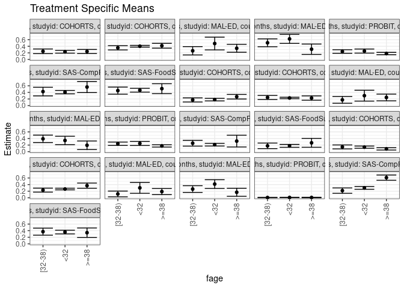

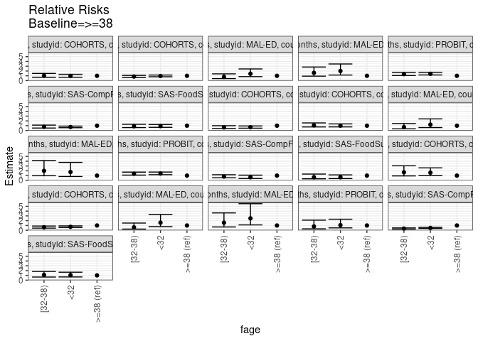

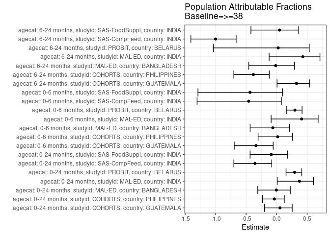

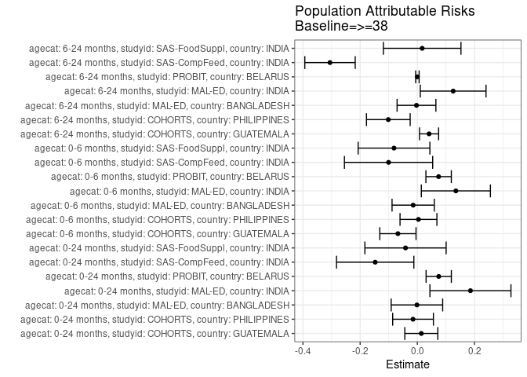

## Results Table

### Parameter: TSM

| agecat | studyid | country | intervention_level | baseline_level | estimate | ci_lower | ci_upper |
| --- | --- | --- | --- | --- | --- | --- | --- |
| 0-24 months | COHORTS | GUATEMALA | >=38 | NA | 0.2420942 | 0.1799521 | 0.3042363 |
| 0-24 months | COHORTS | GUATEMALA | <32 | NA | 0.2331633 | 0.1918973 | 0.2744293 |
| 0-24 months | COHORTS | GUATEMALA | [32-38) | NA | 0.2477554 | 0.1771549 | 0.3183559 |
| 0-24 months | COHORTS | PHILIPPINES | >=38 | NA | 0.4169066 | 0.3441871 | 0.4896261 |
| 0-24 months | COHORTS | PHILIPPINES | <32 | NA | 0.4010445 | 0.3742490 | 0.4278400 |
| 0-24 months | COHORTS | PHILIPPINES | [32-38) | NA | 0.3538514 | 0.2889972 | 0.4187057 |
| 0-24 months | MAL-ED | BANGLADESH | >=38 | NA | 0.3391652 | 0.2192519 | 0.4590785 |
| 0-24 months | MAL-ED | BANGLADESH | <32 | NA | 0.4832699 | 0.2901475 | 0.6763922 |
| 0-24 months | MAL-ED | BANGLADESH | [32-38) | NA | 0.2631701 | 0.1371186 | 0.3892216 |
| 0-24 months | MAL-ED | INDIA | >=38 | NA | 0.3111671 | 0.1543371 | 0.4679972 |
| 0-24 months | MAL-ED | INDIA | <32 | NA | 0.6236448 | 0.4881299 | 0.7591597 |
| 0-24 months | MAL-ED | INDIA | [32-38) | NA | 0.5054198 | 0.3862748 | 0.6245649 |
| 0-24 months | PROBIT | BELARUS | >=38 | NA | 0.1790858 | 0.1425675 | 0.2156041 |
| 0-24 months | PROBIT | BELARUS | <32 | NA | 0.2550435 | 0.1933004 | 0.3167866 |
| 0-24 months | PROBIT | BELARUS | [32-38) | NA | 0.2412632 | 0.1876909 | 0.2948354 |
| 0-24 months | SAS-CompFeed | INDIA | >=38 | NA | 0.5619996 | 0.3937456 | 0.7302536 |
| 0-24 months | SAS-CompFeed | INDIA | <32 | NA | 0.4072548 | 0.3554343 | 0.4590754 |
| 0-24 months | SAS-CompFeed | INDIA | [32-38) | NA | 0.4244577 | 0.2937446 | 0.5551709 |
| 0-24 months | SAS-FoodSuppl | INDIA | >=38 | NA | 0.5126595 | 0.3625043 | 0.6628148 |
| 0-24 months | SAS-FoodSuppl | INDIA | <32 | NA | 0.4658614 | 0.4081692 | 0.5235536 |
| 0-24 months | SAS-FoodSuppl | INDIA | [32-38) | NA | 0.4532715 | 0.3458831 | 0.5606599 |
| 0-6 months | COHORTS | GUATEMALA | >=38 | NA | 0.2685209 | 0.1991963 | 0.3378455 |
| 0-6 months | COHORTS | GUATEMALA | <32 | NA | 0.1810336 | 0.1417173 | 0.2203498 |
| 0-6 months | COHORTS | GUATEMALA | [32-38) | NA | 0.1710117 | 0.1090015 | 0.2330218 |
| 0-6 months | COHORTS | PHILIPPINES | >=38 | NA | 0.2281770 | 0.1624383 | 0.2939157 |
| 0-6 months | COHORTS | PHILIPPINES | <32 | NA | 0.2303479 | 0.2081880 | 0.2525078 |
| 0-6 months | COHORTS | PHILIPPINES | [32-38) | NA | 0.2463362 | 0.1849944 | 0.3076781 |
| 0-6 months | MAL-ED | BANGLADESH | >=38 | NA | 0.2463768 | 0.1443667 | 0.3483870 |
| 0-6 months | MAL-ED | BANGLADESH | <32 | NA | 0.3000000 | 0.1354719 | 0.4645281 |
| 0-6 months | MAL-ED | BANGLADESH | [32-38) | NA | 0.1730769 | 0.0699098 | 0.2762441 |
| 0-6 months | MAL-ED | INDIA | >=38 | NA | 0.1944444 | 0.0647578 | 0.3241311 |
| 0-6 months | MAL-ED | INDIA | <32 | NA | 0.3396226 | 0.2117265 | 0.4675188 |
| 0-6 months | MAL-ED | INDIA | [32-38) | NA | 0.3888889 | 0.2759333 | 0.5018445 |
| 0-6 months | PROBIT | BELARUS | >=38 | NA | 0.1740777 | 0.1396628 | 0.2084926 |
| 0-6 months | PROBIT | BELARUS | <32 | NA | 0.2498778 | 0.1878488 | 0.3119068 |
| 0-6 months | PROBIT | BELARUS | [32-38) | NA | 0.2402731 | 0.1895475 | 0.2909986 |
| 0-6 months | SAS-CompFeed | INDIA | >=38 | NA | 0.3203655 | 0.1419059 | 0.4988251 |
| 0-6 months | SAS-CompFeed | INDIA | <32 | NA | 0.2115571 | 0.1714884 | 0.2516257 |
| 0-6 months | SAS-CompFeed | INDIA | [32-38) | NA | 0.2558912 | 0.1689365 | 0.3428459 |
| 0-6 months | SAS-FoodSuppl | INDIA | >=38 | NA | 0.2681973 | 0.1338389 | 0.4025557 |
| 0-6 months | SAS-FoodSuppl | INDIA | <32 | NA | 0.1763936 | 0.1323464 | 0.2204409 |
| 0-6 months | SAS-FoodSuppl | INDIA | [32-38) | NA | 0.1767518 | 0.0926209 | 0.2608828 |
| 6-24 months | COHORTS | GUATEMALA | >=38 | NA | 0.0851230 | 0.0495106 | 0.1207354 |
| 6-24 months | COHORTS | GUATEMALA | <32 | NA | 0.1368022 | 0.1028741 | 0.1707304 |
| 6-24 months | COHORTS | GUATEMALA | [32-38) | NA | 0.1436823 | 0.0835594 | 0.2038051 |
| 6-24 months | COHORTS | PHILIPPINES | >=38 | NA | 0.3676861 | 0.2894652 | 0.4459070 |
| 6-24 months | COHORTS | PHILIPPINES | <32 | NA | 0.2651949 | 0.2397040 | 0.2906857 |
| 6-24 months | COHORTS | PHILIPPINES | [32-38) | NA | 0.2323400 | 0.1721543 | 0.2925257 |
| 6-24 months | MAL-ED | BANGLADESH | >=38 | NA | 0.1884058 | 0.0958331 | 0.2809785 |
| 6-24 months | MAL-ED | BANGLADESH | <32 | NA | 0.3000000 | 0.1354719 | 0.4645281 |
| 6-24 months | MAL-ED | BANGLADESH | [32-38) | NA | 0.1153846 | 0.0282601 | 0.2025091 |
| 6-24 months | MAL-ED | INDIA | >=38 | NA | 0.1666667 | 0.0445476 | 0.2887858 |
| 6-24 months | MAL-ED | INDIA | <32 | NA | 0.4150943 | 0.2820246 | 0.5481641 |
| 6-24 months | MAL-ED | INDIA | [32-38) | NA | 0.2638889 | 0.1617674 | 0.3660104 |
| 6-24 months | PROBIT | BELARUS | >=38 | NA | 0.0081633 | 0.0010716 | 0.0152549 |
| 6-24 months | PROBIT | BELARUS | <32 | NA | 0.0087439 | 0.0047147 | 0.0127730 |
| 6-24 months | PROBIT | BELARUS | [32-38) | NA | 0.0065359 | 0.0019147 | 0.0111572 |
| 6-24 months | SAS-CompFeed | INDIA | >=38 | NA | 0.6106108 | 0.5309083 | 0.6903133 |
| 6-24 months | SAS-CompFeed | INDIA | <32 | NA | 0.2996310 | 0.2567729 | 0.3424891 |
| 6-24 months | SAS-CompFeed | INDIA | [32-38) | NA | 0.2170291 | 0.1357884 | 0.2982697 |
| 6-24 months | SAS-FoodSuppl | INDIA | >=38 | NA | 0.3388172 | 0.1957899 | 0.4818445 |
| 6-24 months | SAS-FoodSuppl | INDIA | <32 | NA | 0.3584107 | 0.3020422 | 0.4147791 |
| 6-24 months | SAS-FoodSuppl | INDIA | [32-38) | NA | 0.3701311 | 0.2633940 | 0.4768681 |

### Parameter: E(Y)

| agecat | studyid | country | intervention_level | baseline_level | estimate | ci_lower | ci_upper |
| --- | --- | --- | --- | --- | --- | --- | --- |
| 0-24 months | COHORTS | GUATEMALA | NA | NA | 0.2560311 | 0.2321591 | 0.2799032 |
| 0-24 months | COHORTS | PHILIPPINES | NA | NA | 0.4018374 | 0.3841095 | 0.4195652 |
| 0-24 months | MAL-ED | BANGLADESH | NA | NA | 0.3377483 | 0.2620632 | 0.4134335 |
| 0-24 months | MAL-ED | INDIA | NA | NA | 0.4968944 | 0.4194215 | 0.5743673 |
| 0-24 months | PROBIT | BELARUS | NA | NA | 0.2538395 | 0.1952096 | 0.3124695 |
| 0-24 months | SAS-CompFeed | INDIA | NA | NA | 0.4145695 | 0.3576236 | 0.4715155 |
| 0-24 months | SAS-FoodSuppl | INDIA | NA | NA | 0.4712919 | 0.4233811 | 0.5192026 |
| 0-6 months | COHORTS | GUATEMALA | NA | NA | 0.2005842 | 0.1760818 | 0.2250867 |
| 0-6 months | COHORTS | PHILIPPINES | NA | NA | 0.2321307 | 0.2168619 | 0.2473995 |
| 0-6 months | MAL-ED | BANGLADESH | NA | NA | 0.2317881 | 0.1642594 | 0.2993168 |
| 0-6 months | MAL-ED | INDIA | NA | NA | 0.3291925 | 0.2563790 | 0.4020061 |
| 0-6 months | PROBIT | BELARUS | NA | NA | 0.2484793 | 0.1896843 | 0.3072742 |
| 0-6 months | SAS-CompFeed | INDIA | NA | NA | 0.2197071 | 0.1750081 | 0.2644060 |
| 0-6 months | SAS-FoodSuppl | INDIA | NA | NA | 0.1866029 | 0.1492099 | 0.2239959 |
| 6-24 months | COHORTS | GUATEMALA | NA | NA | 0.1261803 | 0.1071047 | 0.1452559 |
| 6-24 months | COHORTS | PHILIPPINES | NA | NA | 0.2661765 | 0.2495644 | 0.2827886 |
| 6-24 months | MAL-ED | BANGLADESH | NA | NA | 0.1854305 | 0.1232352 | 0.2476257 |
| 6-24 months | MAL-ED | INDIA | NA | NA | 0.2919255 | 0.2214783 | 0.3623726 |
| 6-24 months | PROBIT | BELARUS | NA | NA | 0.0083792 | 0.0045582 | 0.0122002 |
| 6-24 months | SAS-CompFeed | INDIA | NA | NA | 0.3051948 | 0.2633957 | 0.3469939 |
| 6-24 months | SAS-FoodSuppl | INDIA | NA | NA | 0.3557214 | 0.3088651 | 0.4025777 |

### Parameter: RR

| agecat | studyid | country | intervention_level | baseline_level | estimate | ci_lower | ci_upper |
| --- | --- | --- | --- | --- | --- | --- | --- |
| 0-24 months | COHORTS | GUATEMALA | >=38 | >=38 | 1.0000000 | 1.0000000 | 1.0000000 |
| 0-24 months | COHORTS | GUATEMALA | <32 | >=38 | 0.9631099 | 0.7060000 | 1.3138535 |
| 0-24 months | COHORTS | GUATEMALA | [32-38) | >=38 | 1.0233842 | 0.6983922 | 1.4996092 |
| 0-24 months | COHORTS | PHILIPPINES | >=38 | >=38 | 1.0000000 | 1.0000000 | 1.0000000 |
| 0-24 months | COHORTS | PHILIPPINES | <32 | >=38 | 0.9619529 | 0.7980783 | 1.1594770 |
| 0-24 months | COHORTS | PHILIPPINES | [32-38) | >=38 | 0.8487548 | 0.6590351 | 1.0930900 |
| 0-24 months | MAL-ED | BANGLADESH | >=38 | >=38 | 1.0000000 | 1.0000000 | 1.0000000 |
| 0-24 months | MAL-ED | BANGLADESH | <32 | >=38 | 1.4248804 | 0.8345789 | 2.4327051 |
| 0-24 months | MAL-ED | BANGLADESH | [32-38) | >=38 | 0.7759349 | 0.4277431 | 1.4075620 |
| 0-24 months | MAL-ED | INDIA | >=38 | >=38 | 1.0000000 | 1.0000000 | 1.0000000 |
| 0-24 months | MAL-ED | INDIA | <32 | >=38 | 2.0042118 | 1.1566011 | 3.4729908 |
| 0-24 months | MAL-ED | INDIA | [32-38) | >=38 | 1.6242713 | 0.9301056 | 2.8365139 |
| 0-24 months | PROBIT | BELARUS | >=38 | >=38 | 1.0000000 | 1.0000000 | 1.0000000 |
| 0-24 months | PROBIT | BELARUS | <32 | >=38 | 1.4241413 | 1.1766363 | 1.7237090 |
| 0-24 months | PROBIT | BELARUS | [32-38) | >=38 | 1.3471931 | 1.0675358 | 1.7001108 |
| 0-24 months | SAS-CompFeed | INDIA | >=38 | >=38 | 1.0000000 | 1.0000000 | 1.0000000 |
| 0-24 months | SAS-CompFeed | INDIA | <32 | >=38 | 0.7246533 | 0.5773474 | 0.9095430 |
| 0-24 months | SAS-CompFeed | INDIA | [32-38) | >=38 | 0.7552635 | 0.5094567 | 1.1196691 |
| 0-24 months | SAS-FoodSuppl | INDIA | >=38 | >=38 | 1.0000000 | 1.0000000 | 1.0000000 |
| 0-24 months | SAS-FoodSuppl | INDIA | <32 | >=38 | 0.9087150 | 0.6611013 | 1.2490716 |
| 0-24 months | SAS-FoodSuppl | INDIA | [32-38) | >=38 | 0.8841570 | 0.6066123 | 1.2886875 |
| 0-6 months | COHORTS | GUATEMALA | >=38 | >=38 | 1.0000000 | 1.0000000 | 1.0000000 |
| 0-6 months | COHORTS | GUATEMALA | <32 | >=38 | 0.6741880 | 0.4813517 | 0.9442772 |
| 0-6 months | COHORTS | GUATEMALA | [32-38) | >=38 | 0.6368653 | 0.4081776 | 0.9936787 |
| 0-6 months | COHORTS | PHILIPPINES | >=38 | >=38 | 1.0000000 | 1.0000000 | 1.0000000 |
| 0-6 months | COHORTS | PHILIPPINES | <32 | >=38 | 1.0095142 | 0.7450455 | 1.3678614 |
| 0-6 months | COHORTS | PHILIPPINES | [32-38) | >=38 | 1.0795840 | 0.7376679 | 1.5799815 |
| 0-6 months | MAL-ED | BANGLADESH | >=38 | >=38 | 1.0000000 | 1.0000000 | 1.0000000 |
| 0-6 months | MAL-ED | BANGLADESH | <32 | >=38 | 1.2176471 | 0.6124737 | 2.4207805 |
| 0-6 months | MAL-ED | BANGLADESH | [32-38) | >=38 | 0.7024887 | 0.3399717 | 1.4515632 |
| 0-6 months | MAL-ED | INDIA | >=38 | >=38 | 1.0000000 | 1.0000000 | 1.0000000 |
| 0-6 months | MAL-ED | INDIA | <32 | >=38 | 1.7466307 | 0.8120101 | 3.7569961 |
| 0-6 months | MAL-ED | INDIA | [32-38) | >=38 | 2.0000000 | 0.9662673 | 4.1396415 |
| 0-6 months | PROBIT | BELARUS | >=38 | >=38 | 1.0000000 | 1.0000000 | 1.0000000 |
| 0-6 months | PROBIT | BELARUS | <32 | >=38 | 1.4354383 | 1.1843643 | 1.7397377 |
| 0-6 months | PROBIT | BELARUS | [32-38) | >=38 | 1.3802630 | 1.1034618 | 1.7264994 |
| 0-6 months | SAS-CompFeed | INDIA | >=38 | >=38 | 1.0000000 | 1.0000000 | 1.0000000 |
| 0-6 months | SAS-CompFeed | INDIA | <32 | >=38 | 0.6603616 | 0.3987250 | 1.0936796 |
| 0-6 months | SAS-CompFeed | INDIA | [32-38) | >=38 | 0.7987476 | 0.5424115 | 1.1762247 |
| 0-6 months | SAS-FoodSuppl | INDIA | >=38 | >=38 | 1.0000000 | 1.0000000 | 1.0000000 |
| 0-6 months | SAS-FoodSuppl | INDIA | <32 | >=38 | 0.6577010 | 0.3759522 | 1.1505999 |
| 0-6 months | SAS-FoodSuppl | INDIA | [32-38) | >=38 | 0.6590366 | 0.3295658 | 1.3178834 |
| 6-24 months | COHORTS | GUATEMALA | >=38 | >=38 | 1.0000000 | 1.0000000 | 1.0000000 |
| 6-24 months | COHORTS | GUATEMALA | <32 | >=38 | 1.6071130 | 0.9888553 | 2.6119210 |
| 6-24 months | COHORTS | GUATEMALA | [32-38) | >=38 | 1.6879381 | 0.9350117 | 3.0471649 |
| 6-24 months | COHORTS | PHILIPPINES | >=38 | >=38 | 1.0000000 | 1.0000000 | 1.0000000 |
| 6-24 months | COHORTS | PHILIPPINES | <32 | >=38 | 0.7212535 | 0.5711256 | 0.9108446 |
| 6-24 months | COHORTS | PHILIPPINES | [32-38) | >=38 | 0.6318978 | 0.4519704 | 0.8834534 |
| 6-24 months | MAL-ED | BANGLADESH | >=38 | >=38 | 1.0000000 | 1.0000000 | 1.0000000 |
| 6-24 months | MAL-ED | BANGLADESH | <32 | >=38 | 1.5923077 | 0.7624990 | 3.3251767 |
| 6-24 months | MAL-ED | BANGLADESH | [32-38) | >=38 | 0.6124260 | 0.2487773 | 1.5076363 |
| 6-24 months | MAL-ED | INDIA | >=38 | >=38 | 1.0000000 | 1.0000000 | 1.0000000 |
| 6-24 months | MAL-ED | INDIA | <32 | >=38 | 2.4905660 | 1.1193351 | 5.5416104 |
| 6-24 months | MAL-ED | INDIA | [32-38) | >=38 | 1.5833333 | 0.6913573 | 3.6261201 |
| 6-24 months | PROBIT | BELARUS | >=38 | >=38 | 1.0000000 | 1.0000000 | 1.0000000 |
| 6-24 months | PROBIT | BELARUS | <32 | >=38 | 1.0711219 | 0.4964948 | 2.3108038 |
| 6-24 months | PROBIT | BELARUS | [32-38) | >=38 | 0.8006536 | 0.3030215 | 2.1155137 |
| 6-24 months | SAS-CompFeed | INDIA | >=38 | >=38 | 1.0000000 | 1.0000000 | 1.0000000 |
| 6-24 months | SAS-CompFeed | INDIA | <32 | >=38 | 0.4907070 | 0.3994595 | 0.6027981 |
| 6-24 months | SAS-CompFeed | INDIA | [32-38) | >=38 | 0.3554295 | 0.2586265 | 0.4884654 |
| 6-24 months | SAS-FoodSuppl | INDIA | >=38 | >=38 | 1.0000000 | 1.0000000 | 1.0000000 |
| 6-24 months | SAS-FoodSuppl | INDIA | <32 | >=38 | 1.0578290 | 0.6739712 | 1.6603116 |
| 6-24 months | SAS-FoodSuppl | INDIA | [32-38) | >=38 | 1.0924211 | 0.6547888 | 1.8225479 |

### Parameter: PAR

| agecat | studyid | country | intervention_level | baseline_level | estimate | ci_lower | ci_upper |
| --- | --- | --- | --- | --- | --- | --- | --- |
| 0-24 months | COHORTS | GUATEMALA | >=38 | NA | 0.0139369 | -0.0437969 | 0.0716707 |
| 0-24 months | COHORTS | PHILIPPINES | >=38 | NA | -0.0150692 | -0.0862969 | 0.0561584 |
| 0-24 months | MAL-ED | BANGLADESH | >=38 | NA | -0.0014169 | -0.0914564 | 0.0886227 |
| 0-24 months | MAL-ED | INDIA | >=38 | NA | 0.1857273 | 0.0440297 | 0.3274249 |
| 0-24 months | PROBIT | BELARUS | >=38 | NA | 0.0747537 | 0.0305874 | 0.1189200 |
| 0-24 months | SAS-CompFeed | INDIA | >=38 | NA | -0.1474300 | -0.2826795 | -0.0121805 |
| 0-24 months | SAS-FoodSuppl | INDIA | >=38 | NA | -0.0413677 | -0.1834583 | 0.1007230 |
| 0-6 months | COHORTS | GUATEMALA | >=38 | NA | -0.0679367 | -0.1312737 | -0.0045997 |
| 0-6 months | COHORTS | PHILIPPINES | >=38 | NA | 0.0039537 | -0.0605361 | 0.0684435 |
| 0-6 months | MAL-ED | BANGLADESH | >=38 | NA | -0.0145887 | -0.0884536 | 0.0592761 |
| 0-6 months | MAL-ED | INDIA | >=38 | NA | 0.1347481 | 0.0139215 | 0.2555747 |
| 0-6 months | PROBIT | BELARUS | >=38 | NA | 0.0744015 | 0.0299494 | 0.1188536 |
| 0-6 months | SAS-CompFeed | INDIA | >=38 | NA | -0.1006585 | -0.2549842 | 0.0536672 |
| 0-6 months | SAS-FoodSuppl | INDIA | >=38 | NA | -0.0815944 | -0.2070321 | 0.0438433 |
| 6-24 months | COHORTS | GUATEMALA | >=38 | NA | 0.0410573 | 0.0076688 | 0.0744458 |
| 6-24 months | COHORTS | PHILIPPINES | >=38 | NA | -0.1015096 | -0.1779273 | -0.0250920 |
| 6-24 months | MAL-ED | BANGLADESH | >=38 | NA | -0.0029753 | -0.0708431 | 0.0648925 |
| 6-24 months | MAL-ED | INDIA | >=38 | NA | 0.1252588 | 0.0103385 | 0.2401791 |
| 6-24 months | PROBIT | BELARUS | >=38 | NA | 0.0002159 | -0.0058072 | 0.0062391 |
| 6-24 months | SAS-CompFeed | INDIA | >=38 | NA | -0.3054160 | -0.3935477 | -0.2172843 |
| 6-24 months | SAS-FoodSuppl | INDIA | >=38 | NA | 0.0169042 | -0.1187579 | 0.1525663 |

### Parameter: PAF

| agecat | studyid | country | intervention_level | baseline_level | estimate | ci_lower | ci_upper |
| --- | --- | --- | --- | --- | --- | --- | --- |
| 0-24 months | COHORTS | GUATEMALA | >=38 | NA | 0.0544345 | -0.2001951 | 0.2550427 |
| 0-24 months | COHORTS | PHILIPPINES | >=38 | NA | -0.0375008 | -0.2308845 | 0.1255005 |
| 0-24 months | MAL-ED | BANGLADESH | >=38 | NA | -0.0041950 | -0.3094728 | 0.2299133 |
| 0-24 months | MAL-ED | INDIA | >=38 | NA | 0.3737762 | 0.0094231 | 0.6041132 |
| 0-24 months | PROBIT | BELARUS | >=38 | NA | 0.2944920 | 0.1542143 | 0.4115039 |
| 0-24 months | SAS-CompFeed | INDIA | >=38 | NA | -0.3556220 | -0.7012932 | -0.0801847 |
| 0-24 months | SAS-FoodSuppl | INDIA | >=38 | NA | -0.0877751 | -0.4353124 | 0.1756118 |
| 0-6 months | COHORTS | GUATEMALA | >=38 | NA | -0.3386940 | -0.6949642 | -0.0573095 |
| 0-6 months | COHORTS | PHILIPPINES | >=38 | NA | 0.0170323 | -0.3039696 | 0.2590122 |
| 0-6 months | MAL-ED | BANGLADESH | >=38 | NA | -0.0629400 | -0.4342828 | 0.2122604 |
| 0-6 months | MAL-ED | INDIA | >=38 | NA | 0.4093291 | -0.0907885 | 0.6801469 |
| 0-6 months | PROBIT | BELARUS | >=38 | NA | 0.2994275 | 0.1588186 | 0.4165328 |
| 0-6 months | SAS-CompFeed | INDIA | >=38 | NA | -0.4581485 | -1.3037938 | 0.0770888 |
| 0-6 months | SAS-FoodSuppl | INDIA | >=38 | NA | -0.4372624 | -1.2897477 | 0.0978381 |
| 6-24 months | COHORTS | GUATEMALA | >=38 | NA | 0.3253861 | 0.0066577 | 0.5418458 |
| 6-24 months | COHORTS | PHILIPPINES | >=38 | NA | -0.3813621 | -0.7016483 | -0.1213606 |
| 6-24 months | MAL-ED | BANGLADESH | >=38 | NA | -0.0160455 | -0.4566198 | 0.2912711 |
| 6-24 months | MAL-ED | INDIA | >=38 | NA | 0.4290780 | -0.1233081 | 0.7098286 |
| 6-24 months | PROBIT | BELARUS | >=38 | NA | 0.0257691 | -1.0373951 | 0.5341474 |
| 6-24 months | SAS-CompFeed | INDIA | >=38 | NA | -1.0007249 | -1.4059186 | -0.6637720 |
| 6-24 months | SAS-FoodSuppl | INDIA | >=38 | NA | 0.0475209 | -0.4214706 | 0.3617761 |